# Os Impactos da Política Monetária na Taxa de Câmbio no Brasil

Ari Araújo & Luiz Araújo

10/07/2020

# DIFERENÇA DAS VARIÁVIES

1.VARIAÇÃO DI

Colentando os dados onde **NÃO** houve reuniões do copom

```r
##DI SEM  COPOM TERCA
dados.sem.copom.t <- read_excel("C:/Users/rprog/Desktop/Dados.xlsx",
                         sheet = "sem copom terca")  #aba onde esta os dados de terca s copom

##DI SEM  COPOM QUINTA
dados.sem.copom.q <- read_excel("C:/Users/rprog/Desktop/Dados.xlsx",
                             sheet = "sem copom quinta")  #aba onsde estao os dados sem copom na quinta
```

Colentando os dados onde **HOUVE** reuniões do copom

```r
 dados.com.copom.t <- read_excel("C:/Users/rprog/Desktop/Dados.xlsx",
                          sheet = "com copom terca")

 dados.com.copom.q <- read_excel("C:/Users/rprog/Desktop/Dados.xlsx",
                            sheet = "com copom quinta")
```

Variação entre as observações de quinta e terça, onde **NÃO** houve reuniões do copom

```r
di.sem.copom.t <- dados.sem.copom.t$`DI-terca` #DI SEM COPOM TERCA

di.sem.copom.q  <- dados.sem.copom.q$`DI-quinta` #DI SEM COPOM QUINTA

var.di.sem.copom <- log(1+di.sem.copom.q )-log(1+di.sem.copom.t)
```

Variação entre as observações de quinta e terça, onde **HOUVE** reuniões do copom

$$\Delta i_c=log(1+i_{quinta(c)})-log(1+i_{terça(c)})$$

```r
 di.com.copom.t <- dados.com.copom.t$`DI-terca`
 di.com.copom.q <- dados.com.copom.q$`DI-quinta`

 var.di.com.copom <- log(1+di.com.copom.q)-log(1+di.com.copom.t)
```

2. VARIAÇÃO CÂMBIO

$$\Delta e_c=log(e_{quinta(c)})-log(e_{terça(c)})$$
Variação entre as observações de quinta e terça, onde **NÃO** houve reuniões do copom

```r
 cambio.sem.copom.t <- dados.sem.copom.t$`Dólar-terca`
 cambio.sem.copom.q <- dados.sem.copom.q$`Dólar-quinta`

 var.cambio.sem.copom <- log(cambio.sem.copom.q)-log(cambio.sem.copom.t)
```

$$\Delta e_{sc}=log(e_{quinta(sc)})-log(e_{terça(sc)})$$

Variação entre as observações de quinta e terça, onde **HOUVE** reuniões do copom

```r
 cambio.com.copom.t <- dados.com.copom.t$`Dólar-terca`
 cambio.com.copom.q <- dados.com.copom.q$`Dólar-quinta`

 var.cambio.com.copom <- log(cambio.com.copom.q)-log(cambio.com.copom.t)
```

3. VARIAÇÃO SELIC

$$\Delta selic_c=log(1+selic_{quinta(c)})-log(1+selic_{terça(c)})$$

Variação entre as observações de quinta e terça, onde **NÃO** houve reuniões do copom

```r
 selic.sem.copom.t <- dados.sem.copom.t$`Selic-terca`
 selic.sem.copom.q <- dados.sem.copom.q$`Selic-quinta`

 var.selic.sem.copom<- log(1+selic.sem.copom.q)-log(1+selic.sem.copom.t)
```

$$\Delta selic_{sc}=log(1+selic_{quinta(sc)})-log(1+selic_{terça(sc)})$$

Variação entre as observações de quinta e terça, onde **HOUVE** reuniões do copom

```r
 selic.com.copom.t <- dados.com.copom.t$`Selic-terca`
 selic.com.copom.q <- dados.com.copom.q$`Selic-quinta`

 var.selic.com.copom<- log(1+selic.com.copom.q)-log(1+selic.com.copom.t)
```

4. VARIAÇÃO EMBI

$$\Delta embi_c=log(embi_{quinta(c)})-log(embi_{terça(c)})$$

Variação entre as observações de quinta e terça, onde **NÃO** houve reuniões do copom

```r
 embi.sem.copom.t <- dados.sem.copom.t$`Embi Br terca`
 embi.sem.copom.q <- dados.sem.copom.q$`Embi br quinta`

 var.embi.sem.copom.q <- log(embi.sem.copom.q)-log(embi.sem.copom.t)
```

$$\Delta embi_{sc}=log(embi_{quinta(sc)})-log(embi_{terça(sc)})$$

Variação entre as observações de quinta e terça, onde **HOUVE** reuniões do copom

```r
 embi.com.copom.t <- dados.com.copom.t$`embi-terca`
 embi.com.copom.q <- dados.com.copom.q$`embi- quinta`

 var.embi.com.copom.q <- log(embi.com.copom.q)-log(embi.com.copom.t)
```

5. VARIAÇÃO DXY

$$\Delta dxy_c=log(dxy_{quinta(c)})-log(dxy_{terça(c)})$$

Variação entre as observações de quinta e terça, onde **NÃO** houve reuniões do copom

```r
 dxy.sem.copom.t <- dados.sem.copom.t$dxy
 dxy.sem.copom.q <- dados.sem.copom.q$dxy

 var.dxy.sem.copom.q <- log(dxy.sem.copom.q)-log(dxy.sem.copom.t)
```

$$\Delta dxy_{sc}=log(dxy_{quinta(sc)})-log(dxy_{terça(sc)})$$

Variação entre as observações de quinta e terça, onde **HOUVE** reuniões do copom

```r
 dxy.com.copom.t <- dados.com.copom.t$dxy
 dxy.com.copom.q <- dados.com.copom.q$dxy

 var.dxy.com.copom.q <- log(dxy.com.copom.q)-log(dxy.com.copom.t)
```

6. VARIAÇÃO VIX

$$\Delta vix_c=log(vix_{quinta(c)})-log(vix_{terça(c)})$$

Variação entre as observações de quinta e terça, onde **NÃO** houve reuniões do copom

```r
 vix.sem.copom.t <- dados.sem.copom.t$vix
 vix.sem.copom.q <- dados.sem.copom.q$vix

 var.vix.sem.copom.q <- log(vix.sem.copom.q)-log(vix.sem.copom.t)
```

$$\Delta vix_{sc}=log(vix_{quinta(sc)})-log(vix_{terça(sc)})$$

Variação entre as observações de quinta e terça, onde **HOUVE** reuniões do copom

```r
 vix.com.copom.t <- dados.com.copom.t$vix
 vix.com.copom.q <- dados.com.copom.q$vix

 var.vix.com.copom.q <- log(vix.com.copom.q)-log(vix.com.copom.t)
```

# CRIANDO VARIÁVEIS E INSTRUMENTOS

## 1. Criando Variáveis

### 1.1 $\Delta I$

Para criar a variável $\Delta I$ é feita a união dos dois conjuntos, como apresentado por Rigobon e Sack (2004)

$$\Delta i= \{ \Delta_{it},t \in C \} \cup \{ \Delta_{it},t \in SC \}, \; C =Copom,\; sc= Sem Copom$$

Como o tamanho das amostras em dias de copom e dias sem são diferentes, devemos fazer o controle pelo tamnho das amostras.

$$\Delta I= \{ \frac{\Delta_{it}}{\sqrt {Tc} },t \in F \} \cup \{ \frac{\Delta_{it}}{\sqrt {Tsc} },t \in F^* \}$$

Dividindo pelo número de observações

```r
length(var.di.com.copom)
```

```
## [1] 73
```

```r
var.di.com.copom.pad <- var.di.com.copom/(sqrt(73))

length(var.di.sem.copom)
```

```
## [1] 389
```

```r
var.di.sem.copom.pad <-var.di.sem.copom/(sqrt(389))
```

Adicionando data nas observações para futuramente ordenar os dados

```r
datas.com.copom <- as.Date(dados.com.copom.t$`Data-terca`)
var.di.com.copom.d <- data.frame(datas.com.copom,round(var.di.com.copom.pad,6))
colnames(var.di.com.copom.d) <- c("Datas","Var DI")


datas.sem.copom <- as.Date(dados.sem.copom.t$`Data- terça`)
var.di.sem.copom.d <- data.frame(datas.sem.copom,round(var.di.sem.copom.pad,6))
colnames(var.di.sem.copom.d) <- c("Datas","Var DI")
```

Unindos as observações em dias de copom com as observações em dias sem copom

```r
var.di <- rbind.data.frame(var.di.com.copom.d,var.di.sem.copom.d)
```

Ordenando as datas

```r
var.di.f <-  var.di[order(var.di$Datas,decreasing = F),]
```

### 1.2 $\Delta E$

A criação do $\Delta E$ é semlhante a criação do $\Delta I$.

$$\Delta e= \{ \Delta_{et},t \in C \} \cup \{ \Delta_{et},t \in SC \},\; C =Copom,\; sc= Sem Copom$$

Fazendo o controle pelo tamanho das amostras.

$$\Delta E= \{ \frac{\Delta_{et}}{\sqrt {Tc} },t \in F \} \cup \{ \frac{\Delta_{et}}{\sqrt {Tsc} },t \in F^* \}$$

Onde $T_C$ e $T_N$ são os tamanhos das amostras.

### *No R*

Dividindo pelo número de observações

```r
length(var.cambio.com.copom)
```

```
## [1] 73
```

```r
var.cambio.com.copom.pad <- var.cambio.com.copom/(sqrt(73))
head(var.cambio.com.copom.pad,4)
```

```
## [1] -0.0007463715 -0.0007924448 -0.0009838280  0.0009672050
```

```r
length(var.cambio.sem.copom)
```

```
## [1] 389
```

```r
var.cambio.sem.copom.pad <-var.cambio.sem.copom/(sqrt(389))
head(var.cambio.sem.copom.pad,4)
```

```
## [1]  0.0006831615 -0.0005576083 -0.0002937509  0.0003314807
```

Adicionando data nas observações

```r
#Datas já foram criadas
var.cambio.com.copom.d <- data.frame(datas.com.copom,round(var.cambio.com.copom.pad,6))
colnames(var.cambio.com.copom.d) <- c("Datas","Var Cambial")

head(var.cambio.com.copom.d,20)
```

```
##         Datas Var Cambial
## 1  2009-07-21   -0.000746
## 2  2009-09-01   -0.000792
## 3  2009-10-20   -0.000984
## 4  2009-12-08    0.000967
## 5  2010-01-26    0.001224
## 6  2010-03-16    0.001200
## 7  2010-04-27   -0.001818
## 8  2010-06-08   -0.003007
## 9  2010-07-20   -0.001130
## 10 2010-08-31   -0.001294
## 11 2010-10-19    0.000201
## 12 2010-12-07    0.001977
## 13 2011-01-18   -0.000210
## 14 2011-03-01   -0.000579
## 15 2011-06-07    0.000836
## 16 2011-07-19   -0.000929
## 17 2011-08-30    0.000997
## 18 2011-10-18    0.000672
## 19 2011-11-29   -0.003576
## 20 2012-01-17   -0.000741
```

```r
var.cambio.sem.copom.d <- data.frame(datas.sem.copom,round(var.cambio.sem.copom.pad,6))
colnames(var.cambio.sem.copom.d) <- c("Datas","Var Cambial")

head(var.cambio.sem.copom.d,20)
```

```
##         Datas Var Cambial
## 1  2009-05-12    0.000683
## 2  2009-05-19   -0.000558
## 3  2009-05-26   -0.000294
## 4  2009-06-02    0.000331
## 5  2009-06-16    0.000642
## 6  2009-06-23   -0.001171
## 7  2009-06-30   -0.000122
## 8  2009-07-14   -0.000946
## 9  2009-07-28   -0.000022
## 10 2009-08-04    0.000211
## 11 2009-08-11   -0.000364
## 12 2009-08-18   -0.000384
## 13 2009-08-25    0.000684
## 14 2009-09-08    0.000019
## 15 2009-09-15    0.000020
## 16 2009-09-22   -0.000406
## 17 2009-09-29   -0.000381
## 18 2009-10-06   -0.000351
## 19 2009-10-13   -0.000771
## 20 2009-10-27    0.000274
```

Unindos as observações em dias de copom com as observações em dias sem copom

```r
var.cambio <- rbind.data.frame(var.cambio.com.copom.d,var.cambio.sem.copom.d)
```

Ordenando as datas

```r
var.cambio.f <-  var.cambio[order(var.cambio$Datas,decreasing = F),]
```

## 2. Criando Instrumentos

### 2.1 $\omega_i$

Os instrumentos equivalem a união de dois conjuntos.

$$\Delta w_i= \{ \Delta_{it},t \in C \} \cup \{- \Delta_{it},t \in SC \},\; C =Copom,\; sc= Sem Copom$$

Também devem ser controlados pelo tamanho da amostra.

$$\Delta w_i= \{ \frac{\Delta_{it}}{\sqrt {Tc} },t \in F \} \cup \{- \frac{\Delta_{it}}{\sqrt {Tsc} },t \in F^* \}$$

#### *No R*

Alterando o sinal das observações

```r
#O DATA FRAME COM COPOM NÃO SERÁ AFETADO

#TROCANDO O SINAL
var.di.sem.copom.pad.sinal <- -var.di.sem.copom.pad


var.di.sem.copom.d.sinal <- data.frame(datas.sem.copom,round(var.di.sem.copom.pad.sinal,6))
colnames(var.di.sem.copom.d.sinal) <- c("Datas","Var DI")

head(var.di.sem.copom.d.sinal,4)
```

```
##        Datas    Var DI
## 1 2009-05-12  0.000436
## 2 2009-05-19 -0.000390
## 3 2009-05-26 -0.000196
## 4 2009-06-02  0.000198
```

Unindos as observações

```r
var.di.sinal <- rbind.data.frame(var.di.com.copom.d,var.di.sem.copom.d.sinal)
```

Ordenando as datas

```r
var.di.sinal.f <-  var.di.sinal[order(var.di.sinal$Datas,decreasing = F),]
```

### 2.2 $\omega_e$

O segundo instrumento é criado de maneira semelhante ao primeiro

$$\Delta w_e= \{ \Delta_{et},t \in C \} \cup \{- \Delta_{et},t \in SC \}, C =Copom, sc= Sem Copom$$

Controlando pelo tamanho da amostra.

$$\Delta w_e= \{ \frac{\Delta_{et}}{\sqrt {Tc} },t \in F \} \cup \{- \frac{\Delta_{et}}{\sqrt {Tsc} },t \in F^* \}$$

#### *No R*

Alterando o sinal das observações

```r
#O DATA FRAME COM COPOM NÃO SERÁ AFETADO

#TROCANDO O SINAL
var.cambio.sem.copom.pad.sinal <- -var.cambio.sem.copom.pad


var.cambio.sem.copom.d.sinal <-       data.frame(datas.sem.copom,round(var.cambio.sem.copom.pad.sinal,6))

colnames(var.cambio.sem.copom.d.sinal) <- c("Datas","Var Cambial")
```

Unindos as observações

```r
var.cambio.sinal <- rbind.data.frame(var.cambio.com.copom.d,var.cambio.sem.copom.d.sinal)
```

Ordenando as datas

```r
var.cambio.sinal.f <-  var.cambio.sinal[order(var.cambio.sinal$Datas,decreasing = F),]
```

## 3. Variáveis Adicionais

### 3.1 VIX

```r
# VIX sem copom
var.vix.sem.copom.d <- data.frame(datas.sem.copom,round(var.vix.sem.copom.q,6))
head(var.vix.sem.copom.d)
```

```
##   datas.sem.copom round.var.vix.sem.copom.q..6.
## 1      2009-05-12                     -0.006135
## 2      2009-05-19                      0.043263
## 3      2009-05-26                      0.018533
## 4      2009-06-02                      0.012628
## 5      2009-06-16                     -0.038645
## 6      2009-06-23                     -0.072008
```

```r
colnames(var.vix.sem.copom.d) <- c("Datas","VIX")
#VIX com copom
var.vix.com.copom.d <- data.frame(datas.com.copom,round(var.vix.com.copom.q,6))
head(var.vix.com.copom.d)
```

```
##   datas.com.copom round.var.vix.com.copom.q..6.
## 1      2009-07-21                     -0.019803
## 2      2009-09-01                     -0.037372
## 3      2009-10-20                     -0.014389
## 4      2009-12-08                     -0.066108
## 5      2010-01-26                     -0.038679
## 6      2010-03-16                     -0.146760
```

```r
colnames(var.vix.com.copom.d) <- c("Datas","VIX")
```

Unindos as observações

```r
var.vix <- rbind.data.frame(var.vix.com.copom.d,var.vix.sem.copom.d)
```

Ordenando as datas

```r
var.vix.f <-  var.vix[order(var.vix$Datas,decreasing = F),]
```

### 3.2 EMBI

```r
# EMBI sem copom
var.embi.sem.copom.d <- data.frame(datas.sem.copom,round(var.embi.sem.copom.q,6))
head(var.embi.sem.copom.d)
```

```
##   datas.sem.copom round.var.embi.sem.copom.q..6.
## 1      2009-05-12                      -0.078781
## 2      2009-05-19                       0.021245
## 3      2009-05-26                      -0.009756
## 4      2009-06-02                      -0.031416
## 5      2009-06-16                      -0.015267
## 6      2009-06-23                       0.014135
```

```r
colnames(var.embi.sem.copom.d) <- c("Datas","EMBI")
#EMBI com copom
var.embi.com.copom.d <- data.frame(datas.com.copom,round(var.embi.com.copom.q,6))
head(var.embi.com.copom.d)
```

```
##   datas.com.copom round.var.embi.com.copom.q..6.
## 1      2009-07-21                      -0.097543
## 2      2009-09-01                      -0.026072
## 3      2009-10-20                      -0.008969
## 4      2009-12-08                      -0.043172
## 5      2010-01-26                       0.040274
## 6      2010-03-16                       0.010417
```

```r
colnames(var.embi.com.copom.d) <- c("Datas","EMBI")
```

Unindos as observações

```r
var.embi <- rbind.data.frame(var.embi.com.copom.d,var.embi.sem.copom.d)
```

Ordenando as datas

```r
var.embi.f <-  var.embi[order(var.embi$Datas,decreasing = F),]
head(var.embi.f,4)
```

```
##         Datas      EMBI
## 74 2009-05-12 -0.078781
## 75 2009-05-19  0.021245
## 76 2009-05-26 -0.009756
## 77 2009-06-02 -0.031416
```

### 3.3 DXY

```r
# DXY sem copom
var.dxy.sem.copom.d <- data.frame(datas.sem.copom,round(var.dxy.sem.copom.q,6))
head(var.dxy.sem.copom.d)
```

```
##   datas.sem.copom round.var.dxy.sem.copom.q..6.
## 1      2009-05-12                      0.002912
## 2      2009-05-19                     -0.005993
## 3      2009-05-26                      0.001625
## 4      2009-06-02                      0.005761
## 5      2009-06-16                     -0.000981
## 6      2009-06-23                      0.001585
```

```r
colnames(var.dxy.sem.copom.d) <- c("Datas","DXY")
# DXY com copom
var.dxy.com.copom.d <- data.frame(datas.com.copom,round(var.dxy.com.copom.q,6))
head(var.dxy.com.copom.d)
```

```
##   datas.com.copom round.var.dxy.com.copom.q..6.
## 1      2009-07-21                     -0.004590
## 2      2009-09-01                     -0.002378
## 3      2009-10-20                     -0.001476
## 4      2009-12-08                      0.000634
## 5      2010-01-26                     -0.000492
## 6      2010-03-16                      0.001410
```

```r
colnames(var.dxy.com.copom.d) <- c("Datas","DXY")
```

Unindos as observações

```r
var.dxy <- rbind.data.frame(var.dxy.com.copom.d,var.dxy.sem.copom.d)
```

Ordenando as datas

```r
var.dxy.f <-  var.dxy[order(var.dxy$Datas,decreasing = F),]
head(var.dxy.f,4)
```

```
##         Datas       DXY
## 74 2009-05-12  0.002912
## 75 2009-05-19 -0.005993
## 76 2009-05-26  0.001625
## 77 2009-06-02  0.005761
```

### CRIANDO DUMMIES

Variáveis na quinta SEM COPOM

```r
a.vista.sem.copom.q <- dados.sem.copom.q$`a vista-quinta`
a.termo.sem.copom.q <- dados.sem.copom.q$`a termo-quinta`
emp.sem.copom.q <- dados.sem.copom.q$`emprestimo em moeda estran-quinta`
recompra.sem.copom.q <- dados.sem.copom.q$`recompra-quinta`
data.sem.cop.q <- dados.sem.copom.q$`Data-quinta`
## df de todas as intervecoes sem copom
df.I.SC <-data.frame(data.sem.cop.q,a.vista.sem.copom.q,a.termo.sem.copom.q,emp.sem.copom.q,recompra.sem.copom.q)


df.I.SC <- transform(df.I.SC, Soma=rowSums(df.I.SC[,2:5])) ## somando todas as intervencoes
colnames(df.I.SC) <- c("Data","A Vista","A Termo","Emprestimo","Recompra","Total_Interv")
head(df.I.SC,4)
```

```
##         Data A Vista A Termo Emprestimo Recompra Total_Interv
## 1 2009-05-14     190       0          8        0          198
## 2 2009-05-21     194       0         45        0          239
## 3 2009-05-28     190       0          3        0          193
## 4 2009-06-04     299       0          2        0          301
```

Criando as dummies pos e neg para dias sem copom

```r
df.I.SC$dummy.int.pos <- ifelse(df.I.SC$Total_Interv>0,1,0)
df.I.SC$dummy.int.neg <- ifelse(df.I.SC$Total_Interv<0,1,0)
colnames(df.I.SC) <- c("Data","A Vista","A Termo","Emprestimo","Recompra","Total_Interv","Dummy_POS","Dummy_Neg")
```

```r
#  juntando em um df e renomeando

df.I.SC.pos<- data.frame(df.I.SC$Data,df.I.SC$Dummy_POS)
df.I.SC.neg <- data.frame(df.I.SC$Data,df.I.SC$Dummy_Neg)
colnames(df.I.SC.pos) <- c("Data","Dummy_POS")
colnames(df.I.SC.neg) <- c("Data","Dummy_NEG")
```

Variáveis na quinta COM COPOM

```r
#variaveis de intervencao
a.vista.com.copom.q <- dados.com.copom.q$`a vista-quinta`
a.termo.com.copom.q <- dados.com.copom.q$`a termo-quinta`
emp.com.copom.q <- dados.com.copom.q$`emprestimo em moeda estran-quinta`
recompra.com.copom.q <- dados.com.copom.q$`recompra-quinta`
data.com.cop.q <- dados.com.copom.q$`Data-quinta`
```

```r
#df intervencao com copom

df.I.CC <-data.frame(data.com.cop.q,a.vista.com.copom.q,a.termo.com.copom.q,emp.com.copom.q,recompra.com.copom.q)
colnames(df.I.CC) <- c("Data","A Vista","A Termo","Emprestimo","Recompra")

df.I.CC<- transform(df.I.CC, Soma=rowSums(df.I.CC[,2:5]))## somando todas as intervencoes
colnames(df.I.CC) <- c("Data","A Vista","A Termo","Emprestimo","Recompra","Total_Interv")
```

Criando as dummies para os dias com reuniões do Copom

```r
df.I.CC$dummy.int.pos <- ifelse(df.I.CC$Total_Interv>0,1,0)
df.I.CC$dummy.int.neg <- ifelse(df.I.CC$Total_Interv<0,1,0)
colnames(df.I.CC) <-c("Data","A Vista","A Termo","Emprestimo","Recompra","Total_Interv","Dummy_POS","Dummy_Neg")

df.I.CC.pos<- data.frame(df.I.CC$Data,df.I.CC$Dummy_POS)
df.I.CC.neg <- data.frame(df.I.CC$Data,df.I.CC$Dummy_Neg)
colnames(df.I.CC.pos) <- c("Data","Dummy_POS")
colnames(df.I.CC.neg) <- c("Data","Dummy_NEG")
```

```r
dta <- c(as.Date(df.I.CC$Data),as.Date(df.I.SC$Data))


df.dummies.pos <- rbind.data.frame(df.I.CC.pos, df.I.SC.pos)
```

Colocando as datas em ordem crescente

```r
df.dummies.pos.f <- df.dummies.pos[order(df.dummies.pos$Data,decreasing = FALSE),]
```

Tabela final com a dummy de intervenção negativa

```r
df.dummies.neg <- rbind.data.frame(df.I.CC.neg, df.I.SC.neg)
```

Colocando as datas em ordem crescente

```r
df.dummies.neg.f <- df.dummies.neg[order(df.dummies.neg$Data,decreasing = FALSE),]
```

# Estimação

Criando matriz com as variáveis que serão utilizadas.

```r
#VAriáveis criadas
WI <- var.di.sinal.f$`Var DI` # primeiro instrumento criado
WE <- var.cambio.sinal.f$`Var Cambial` # segundo instrumento criado

DELTA_I <- var.di.f$`Var DI`# Variavel explicativa (endogena) criada
DELTA_E <- var.cambio.f$`Var Cambial` # Variael explicada criada

#variáveis adicionais
VIX <- var.vix.f$VIX # indice de volatilidade do mercado
EMBI <- var.embi.f$EMBI # risco pais
DXY <- var.dxy.f$DXY # indice do dolar


#Dummies

  #NEgativa
INT.BC.NEG <- df.dummies.neg.f$Dummy_NEG

  #Positiva

INT.BC.POS <- df.dummies.pos.f$Dummy_POS

# todas as variaveis
dados <- data.frame(DELTA_E,DELTA_I,WE,WI,VIX,EMBI,DXY,INT.BC.NEG,INT.BC.POS)
```

Estatísticas das variáveis.

```r
summary(dados)
```

```
##     DELTA_E              DELTA_I                 WE
##  Min.   :-4.207e-03   Min.   :-6.169e-03   Min.   :-4.453e-03
##  1st Qu.:-3.588e-04   1st Qu.:-2.927e-04   1st Qu.:-4.465e-04
##  Median : 1.850e-05   Median : 0.000e+00   Median :-1.800e-05
##  Mean   : 3.935e-05   Mean   :-6.874e-06   Mean   :-4.104e-05
##  3rd Qu.: 4.440e-04   3rd Qu.: 2.882e-04   3rd Qu.: 3.540e-04
##  Max.   : 4.453e-03   Max.   : 6.477e-03   Max.   : 3.949e-03
##        WI                  VIX                EMBI
##  Min.   :-0.0064770   Min.   :-5.29760   Min.   :-0.167835
##  1st Qu.:-0.0002927   1st Qu.:-0.16446   1st Qu.:-0.025637
##  Median : 0.0000000   Median :-0.01760   Median : 0.000000
##  Mean   :-0.0000924   Mean   : 0.03028   Mean   :-0.002484
##  3rd Qu.: 0.0002873   3rd Qu.: 0.13050   3rd Qu.: 0.018592
##  Max.   : 0.0046550   Max.   : 6.55749   Max.   : 0.190419
##       DXY               INT.BC.NEG        INT.BC.POS
##  Min.   :-0.0181900   Min.   :0.00000   Min.   :0.0000
##  1st Qu.:-0.0024240   1st Qu.:0.00000   1st Qu.:0.0000
##  Median : 0.0000265   Median :0.00000   Median :0.0000
##  Mean   : 0.0001766   Mean   :0.04545   Mean   :0.2511
##  3rd Qu.: 0.0027912   3rd Qu.:0.00000   3rd Qu.:0.7500
##  Max.   : 0.0226010   Max.   :1.00000   Max.   :1.0000
```

Correlação entre as variávies

```r
cor(dados)
```

```
##                 DELTA_E      DELTA_I           WE           WI         VIX
## DELTA_E     1.000000000 -0.004750742  0.012952313 -0.292868515  0.07932301
## DELTA_I    -0.004750742  1.000000000 -0.296287221  0.249418640  0.12169700
## WE          0.012952313 -0.296287221  1.000000000 -0.009780684 -0.08373192
## WI         -0.292868515  0.249418640 -0.009780684  1.000000000 -0.01010560
## VIX         0.079323015  0.121697002 -0.083731921 -0.010105598  1.00000000
## EMBI        0.159387890  0.040142992  0.089073011 -0.036362696  0.01600978
## DXY         0.520667076  0.062449962 -0.269193111 -0.034233498  0.07655008
## INT.BC.NEG -0.026301853 -0.066981358  0.086514328 -0.014089249 -0.02833731
## INT.BC.POS -0.001324901 -0.040510817 -0.011228874 -0.006085329 -0.02852161
##                     EMBI         DXY    INT.BC.NEG   INT.BC.POS
## DELTA_E     1.593879e-01  0.52066708 -2.630185e-02 -0.001324901
## DELTA_I     4.014299e-02  0.06244996 -6.698136e-02 -0.040510817
## WE          8.907301e-02 -0.26919311  8.651433e-02 -0.011228874
## WI         -3.636270e-02 -0.03423350 -1.408925e-02 -0.006085329
## VIX         1.600978e-02  0.07655008 -2.833731e-02 -0.028521611
## EMBI        1.000000e+00  0.08947973  6.884116e-05 -0.045647714
## DXY         8.947973e-02  1.00000000 -3.400332e-02 -0.028740940
## INT.BC.NEG  6.884116e-05 -0.03400332  1.000000e+00 -0.126351761
## INT.BC.POS -4.564771e-02 -0.02874094 -1.263518e-01  1.000000000
```

## Estimação por MQO

```r
mqo <- lm(DELTA_E~DELTA_I)
summary(mqo)
```

```
##
## Call:
## lm(formula = DELTA_E ~ DELTA_I)
##
## Residuals:
##        Min         1Q     Median         3Q        Max
## -0.0042456 -0.0003984 -0.0000206  0.0004057  0.0044421
##
## Coefficients:
##               Estimate Std. Error t value Pr(>|t|)
## (Intercept)  3.932e-05  4.048e-05   0.971    0.332
## DELTA_I     -4.390e-03  4.308e-02  -0.102    0.919
##
## Residual standard error: 0.00087 on 460 degrees of freedom
## Multiple R-squared:  2.257e-05,  Adjusted R-squared:  -0.002151
## F-statistic: 0.01038 on 1 and 460 DF,  p-value: 0.9189
```

```r
coef3 <- round((coefficients(mqo)),4)
coef3
```

```
## (Intercept)     DELTA_I
##      0.0000     -0.0044
```

## Estimação por MQ2E.

### Estimação utilizando apenas $\Delta I$ como variável

Estimação com $\omega_i$ como instrumento.

```r
#Apenas WI como instrumento
iv1 <- ivreg(formula =DELTA_E~ DELTA_I |WI,data = dados )
summary(iv1,diagnostics = T)
```

```
##
## Call:
## ivreg(formula = DELTA_E ~ DELTA_I | WI, data = dados)
##
## Residuals:
##        Min         1Q     Median         3Q        Max
## -5.728e-03 -5.373e-04  3.519e-06  5.318e-04  1.145e-02
##
## Coefficients:
##               Estimate Std. Error t value Pr(>|t|)
## (Intercept)  3.189e-05  6.231e-05   0.512    0.609
## DELTA_I     -1.085e+00  2.658e-01  -4.082 5.26e-05 ***
##
## Diagnostic tests:
##                  df1 df2 statistic  p-value
## Weak instruments   1 460     30.52 5.55e-08 ***
## Wu-Hausman         1 459     45.80 4.01e-11 ***
## Sargan             0  NA        NA       NA
## ---
## Signif. codes:  0 '***' 0.001 '**' 0.01 '*' 0.05 '.' 0.1 ' ' 1
##
## Residual standard error: 0.001339 on 460 degrees of freedom
## Multiple R-Squared: -1.368,  Adjusted R-squared: -1.373
## Wald test: 16.66 on 1 and 460 DF,  p-value: 5.26e-05
```

```r
coef1 <- round((coefficients(iv1)),6)
print(coef1)
```

```
## (Intercept)     DELTA_I
##    0.000032   -1.085037
```

Estimação com $\omega_i$ e $\omega_e$ como instrumentos.

```r
#WI e WE como instrumentos
iv2 <- ivreg(formula = DELTA_E~DELTA_I |WI+WE,data = dados )
summary(iv2,diagnostics = T)
```

```
##
## Call:
## ivreg(formula = DELTA_E ~ DELTA_I | WI + WE, data = dados)
##
## Residuals:
##        Min         1Q     Median         3Q        Max
## -4.169e-03 -4.217e-04 -5.178e-06  4.110e-04  7.479e-03
##
## Coefficients:
##               Estimate Std. Error t value Pr(>|t|)
## (Intercept)  3.610e-05  4.539e-05   0.795 0.426821
## DELTA_I     -4.728e-01  1.253e-01  -3.773 0.000183 ***
##
## Diagnostic tests:
##                  df1 df2 statistic  p-value
## Weak instruments   2 459     40.05  < 2e-16 ***
## Wu-Hausman         1 459     21.54 4.52e-06 ***
## Sargan             1  NA     17.27 3.24e-05 ***
## ---
## Signif. codes:  0 '***' 0.001 '**' 0.01 '*' 0.05 '.' 0.1 ' ' 1
##
## Residual standard error: 0.0009754 on 460 degrees of freedom
## Multiple R-Squared: -0.2569, Adjusted R-squared: -0.2596
## Wald test: 14.23 on 1 and 460 DF,  p-value: 0.0001826
```

```r
coef2 <- round((coefficients(iv2)),6)
print(coef2)
```

```
## (Intercept)     DELTA_I
##    0.000036   -0.472786
```

### Estimação utilizando todas as variáveis criadas

Estimação com $\omega_i$ como instrumento.

```r
#Documentação do ivreg:For example, if there is one exogenous regressor 'ex' and one endogenous regressor 'en' with instrument 'in', the appropriate formula would be y ~ ex + en | ex + in. Equivalently, this can be specified as y ~ ex + en | . - en + in .


#Apenas WI como instrumento
iv3 <- ivreg(formula = DELTA_E~DELTA_I + EMBI + DXY + VIX + INT.BC.NEG + INT.BC.POS |. -DELTA_I + WI,data = dados )
summary(iv3,diagnostics=TRUE)
```

```
##
## Call:
## ivreg(formula = DELTA_E ~ DELTA_I + EMBI + DXY + VIX + INT.BC.NEG +
##     INT.BC.POS | . - DELTA_I + WI, data = dados)
##
## Residuals:
##        Min         1Q     Median         3Q        Max
## -4.878e-03 -4.587e-04 -2.521e-05  4.534e-04  1.012e-02
##
## Coefficients:
##               Estimate Std. Error t value Pr(>|t|)
## (Intercept)  4.536e-05  6.455e-05   0.703   0.4825
## DELTA_I     -9.928e-01  2.265e-01  -4.383 1.45e-05 ***
## EMBI         3.206e-03  1.352e-03   2.372   0.0181 *
## DXY          1.040e-01  1.182e-02   8.806  < 2e-16 ***
## VIX          1.735e-04  7.304e-05   2.376   0.0179 *
## INT.BC.NEG  -3.256e-04  2.693e-04  -1.209   0.2272
## INT.BC.POS  -5.457e-05  1.269e-04  -0.430   0.6674
##
## Diagnostic tests:
##                  df1 df2 statistic  p-value
## Weak instruments   1 455     31.81 2.99e-08 ***
## Wu-Hausman         1 454     51.12 3.50e-12 ***
## Sargan             0  NA        NA       NA
## ---
## Signif. codes:  0 '***' 0.001 '**' 0.01 '*' 0.05 '.' 0.1 ' ' 1
##
## Residual standard error: 0.001155 on 455 degrees of freedom
## Multiple R-Squared: -0.7427, Adjusted R-squared: -0.7657
## Wald test: 15.64 on 6 and 455 DF,  p-value: 2.383e-16
```

```r
coef3 <- round((coefficients(iv3)),4)
print(coef3)
```

```
## (Intercept)     DELTA_I        EMBI         DXY         VIX  INT.BC.NEG
##      0.0000     -0.9928      0.0032      0.1040      0.0002     -0.0003
##  INT.BC.POS
##     -0.0001
```

Estimação com $\omega_i$ e $\omega_e$ como instrumentos.

```r
#WI e WE como instrumentos
iv4 <- ivreg(formula = DELTA_E~DELTA_I + EMBI + DXY + VIX + INT.BC.NEG + INT.BC.POS |. -DELTA_I + WE+ WI ,data = dados )
summary(iv4 ,diagnostics=TRUE)
```

```
##
## Call:
## ivreg(formula = DELTA_E ~ DELTA_I + EMBI + DXY + VIX + INT.BC.NEG +
##     INT.BC.POS | . - DELTA_I + WE + WI, data = dados)
##
## Residuals:
##        Min         1Q     Median         3Q        Max
## -3.363e-03 -3.916e-04 -7.821e-06  4.026e-04  8.384e-03
##
## Coefficients:
##               Estimate Std. Error t value Pr(>|t|)
## (Intercept)  3.785e-05  5.386e-05   0.703  0.48258
## DELTA_I     -7.093e-01  1.265e-01  -5.608 3.56e-08 ***
## EMBI         2.994e-03  1.126e-03   2.659  0.00811 **
## DXY          1.013e-01  9.791e-03  10.351  < 2e-16 ***
## VIX          1.359e-04  5.816e-05   2.337  0.01987 *
## INT.BC.NEG  -2.392e-04  2.211e-04  -1.082  0.27982
## INT.BC.POS  -2.819e-05  1.053e-04  -0.268  0.78913
##
## Diagnostic tests:
##                  df1 df2 statistic  p-value
## Weak instruments   2 454    38.999 2.34e-16 ***
## Wu-Hausman         1 454    63.301 1.43e-14 ***
## Sargan             1  NA     4.102   0.0428 *
## ---
## Signif. codes:  0 '***' 0.001 '**' 0.01 '*' 0.05 '.' 0.1 ' ' 1
##
## Residual standard error: 0.0009659 on 455 degrees of freedom
## Multiple R-Squared: -0.2192, Adjusted R-squared: -0.2353
## Wald test: 23.02 on 6 and 455 DF,  p-value: < 2.2e-16
```

```r
coef4 <- round((coefficients(iv4)),4)
print(coef4)
```

```
## (Intercept)     DELTA_I        EMBI         DXY         VIX  INT.BC.NEG
##      0.0000     -0.7093      0.0030      0.1013      0.0001     -0.0002
##  INT.BC.POS
##      0.0000
```

## Estimação por GMM

### Estimação utilizando apenas $\Delta I$ como variável

Estimação com $\omega_i$ como instrumento.

```r
#WI como instrumento
reg_gmm1 <- gmm(DELTA_E~DELTA_I,~ WI,data = dados)
summary(reg_gmm1)
```

```
##
## Call:
## gmm(g = DELTA_E ~ DELTA_I, x = ~WI, data = dados)
##
##
## Method:  twoStep
##
## Kernel:  Quadratic Spectral
##
## Coefficients:
##              Estimate     Std. Error   t value      Pr(>|t|)
## (Intercept)   3.1889e-05   6.0587e-05   5.2634e-01   5.9865e-01
## DELTA_I      -1.0850e+00   1.0584e+00  -1.0252e+00   3.0528e-01
##
## J-Test: degrees of freedom is 0
##                 J-test                P-value
## Test E(g)=0:    4.18702933819682e-37  *******
```

```r
coefgmm1 <- round(reg_gmm1$coefficients,6)
sum_gmm1 <- round(coef(summary(reg_gmm1)),6)

print(sum_gmm1)
```

```
##              Estimate Std. Error   t value Pr(>|t|)
## (Intercept)  0.000032   0.000061  0.526343 0.598650
## DELTA_I     -1.085037   1.058381 -1.025185 0.305276
```

Estimação com $\omega_i$ e $\omega_e$ como instrumentos.

```r
#WI e WE como instrumento
reg_gmm2 <- gmm(DELTA_E~DELTA_I , ~WI+WE,data = dados)
summary(reg_gmm2)
```

```
##
## Call:
## gmm(g = DELTA_E ~ DELTA_I, x = ~WI + WE, data = dados)
##
##
## Method:  twoStep
##
## Kernel:  Quadratic Spectral(with bw =  0.67998 )
##
## Coefficients:
##              Estimate     Std. Error   t value      Pr(>|t|)
## (Intercept)   1.8044e-05   4.3389e-05   4.1587e-01   6.7751e-01
## DELTA_I      -4.6729e-01   2.4146e-01  -1.9353e+00   5.2959e-02
##
## J-Test: degrees of freedom is 1
##                 J-test   P-value
## Test E(g)=0:    1.22088  0.26919
##
## Initial values of the coefficients
##   (Intercept)       DELTA_I
##  3.609833e-05 -4.727864e-01
```

```r
coefgmm2 <- round(reg_gmm2$coefficients,6)
sum_gmm2 <- round(coef(summary(reg_gmm2)),6)

print(sum_gmm2)
```

```
##              Estimate Std. Error   t value Pr(>|t|)
## (Intercept)  0.000018   0.000043  0.415868 0.677507
## DELTA_I     -0.467289   0.241462 -1.935252 0.052959
```

### Estimação utilizando todas as variáveis criadas

Estimação com $\omega_i$ como instrumento.

```r
#WI como instrumento
reg_gmm3 <- gmm(DELTA_E~ DELTA_I + EMBI+ VIX + DXY+ INT.BC.NEG + INT.BC.POS,
                ~ WI+ EMBI + VIX + DXY+ INT.BC.NEG + INT.BC.POS,data = dados)
summary(reg_gmm3)
```

```
##
## Call:
## gmm(g = DELTA_E ~ DELTA_I + EMBI + VIX + DXY + INT.BC.NEG + INT.BC.POS,
##     x = ~WI + EMBI + VIX + DXY + INT.BC.NEG + INT.BC.POS, data = dados)
##
##
## Method:  twoStep
##
## Kernel:  Quadratic Spectral
##
## Coefficients:
##              Estimate     Std. Error   t value      Pr(>|t|)
## (Intercept)   4.5363e-05   8.3932e-05   5.4048e-01   5.8887e-01
## DELTA_I      -9.9278e-01   9.1728e-01  -1.0823e+00   2.7911e-01
## EMBI          3.2063e-03   1.5433e-03   2.0775e+00   3.7752e-02
## VIX           1.7355e-04   1.9232e-04   9.0237e-01   3.6686e-01
## DXY           1.0404e-01   1.2892e-02   8.0705e+00   7.0015e-16
## INT.BC.NEG   -3.2564e-04   4.0806e-04  -7.9802e-01   4.2486e-01
## INT.BC.POS   -5.4572e-05   1.3970e-04  -3.9063e-01   6.9607e-01
##
## J-Test: degrees of freedom is 0
##                 J-test                P-value
## Test E(g)=0:    1.31508589098524e-36  *******
```

```r
coefgmm3 <- round(reg_gmm3$coefficients,6)
sum_gmm3 <- round(coef(summary(reg_gmm3)),6)

print(sum_gmm3)
```

```
##              Estimate Std. Error   t value Pr(>|t|)
## (Intercept)  0.000045   0.000084  0.540477 0.588868
## DELTA_I     -0.992785   0.917276 -1.082319 0.279111
## EMBI         0.003206   0.001543  2.077533 0.037752
## VIX          0.000174   0.000192  0.902374 0.366858
## DXY          0.104042   0.012892  8.070493 0.000000
## INT.BC.NEG  -0.000326   0.000408 -0.798022 0.424858
## INT.BC.POS  -0.000055   0.000140 -0.390627 0.696073
```

Estimação com $\omega_i$ e $\omega_e$ como instrumentos.

```r
#WI e WE como instrumento
reg_gmm4 <- gmm(DELTA_E~DELTA_I +EMBI + DXY + VIX + INT.BC.NEG  +  INT.BC.POS,
                ~EMBI + DXY + VIX +  INT.BC.NEG  +  INT.BC.POS  + WI+WE, data = dados)
summary(reg_gmm4)
```

```
##
## Call:
## gmm(g = DELTA_E ~ DELTA_I + EMBI + DXY + VIX + INT.BC.NEG + INT.BC.POS,
##     x = ~EMBI + DXY + VIX + INT.BC.NEG + INT.BC.POS + WI + WE,
##     data = dados)
##
##
## Method:  twoStep
##
## Kernel:  Quadratic Spectral(with bw =  0.76972 )
##
## Coefficients:
##              Estimate     Std. Error   t value      Pr(>|t|)
## (Intercept)   2.5774e-05   5.4437e-05   4.7347e-01   6.3588e-01
## DELTA_I      -6.7866e-01   2.3748e-01  -2.8578e+00   4.2664e-03
## EMBI          2.9108e-03   1.1008e-03   2.6443e+00   8.1867e-03
## DXY           1.0117e-01   8.6579e-03   1.1686e+01   1.5108e-31
## VIX           1.1009e-04   7.3983e-05   1.4880e+00   1.3674e-01
## INT.BC.NEG   -2.1176e-04   2.2594e-04  -9.3724e-01   3.4863e-01
## INT.BC.POS   -1.6662e-05   7.7110e-05  -2.1608e-01   8.2892e-01
##
## J-Test: degrees of freedom is 1
##                 J-test   P-value
## Test E(g)=0:    0.22221  0.63736
##
## Initial values of the coefficients
##   (Intercept)       DELTA_I          EMBI           DXY           VIX
##  3.784915e-05 -7.092789e-01  2.993743e-03  1.013396e-01  1.359229e-04
##    INT.BC.NEG    INT.BC.POS
## -2.392537e-04 -2.818656e-05
```

```r
coefgmm4 <- round(reg_gmm4$coefficients,6)

sum_gmm4 <- round(coef(summary(reg_gmm4)),6)

print(sum_gmm4)
```

```
##              Estimate Std. Error   t value Pr(>|t|)
## (Intercept)  0.000026   0.000054  0.473467 0.635880
## DELTA_I     -0.678660   0.237480 -2.857762 0.004266
## EMBI         0.002911   0.001101  2.644272 0.008187
## DXY          0.101172   0.008658 11.685560 0.000000
## VIX          0.000110   0.000074  1.488024 0.136745
## INT.BC.NEG  -0.000212   0.000226 -0.937241 0.348634
## INT.BC.POS  -0.000017   0.000077 -0.216084 0.828923
```

Breusch-Godfrey: H0: ausência de correlação serial

```r
bgtest(mqo,order=12)
```

```
##
##  Breusch-Godfrey test for serial correlation of order up to 12
##
## data:  mqo
## LM test = 5.458, df = 12, p-value = 0.9409
```

```r
bgtest(iv1,12)
```

```
##
##  Breusch-Godfrey test for serial correlation of order up to 12
##
## data:  iv1
## LM test = 5.458, df = 12, p-value = 0.9409
```

```r
bgtest(iv2,12)
```

```
##
##  Breusch-Godfrey test for serial correlation of order up to 12
##
## data:  iv2
## LM test = 5.458, df = 12, p-value = 0.9409
```

```r
bgtest(iv3,order=12)
```

```
##
##  Breusch-Godfrey test for serial correlation of order up to 12
##
## data:  iv3
## LM test = 9.8528, df = 12, p-value = 0.6289
```

```r
bgtest(iv4,order=12)
```

```
##
##  Breusch-Godfrey test for serial correlation of order up to 12
##
## data:  iv4
## LM test = 9.8528, df = 12, p-value = 0.6289
```

# GRÁFICOS

```r
dados.s.c.t <- dados.sem.copom.t %>%
  select(`Data- terça`,`Dólar-terca`,`DI-terca`,`Embi Br terca`,vix,dxy)
colnames(dados.s.c.t) <- c('Data','Dolar','DI','EMBI','VIX','DXY')


dados.s.c.q <- dados.sem.copom.q %>%
  select(`Data-quinta`,`Dólar-quinta`,`DI-quinta`,`Embi br quinta`,vix,dxy)
colnames(dados.s.c.q) <- c('Data','Dolar','DI','EMBI','VIX','DXY')

dados.s.c <- rbind.data.frame(dados.s.c.q,dados.s.c.t)
dados.s.c <- dados.s.c[order(dados.s.c$Data),]
```

Selecionandos os dados

```r
dados.c.c.t <- dados.com.copom.t %>%
  select(`Data-terca`,`Dólar-terca`,`DI-terca`,`embi-terca`,vix,dxy)
colnames(dados.c.c.t) <- c('Data','Dolar','DI','EMBI','VIX','DXY')


dados.c.c.q <- dados.com.copom.q %>%
  select(`Data-quinta`,`Dólar-quinta`,`DI-quinta`,`embi- quinta`,vix,dxy)
colnames(dados.c.c.q) <- c('Data','Dolar','DI','EMBI','VIX','DXY')


dados.c.c <- rbind.data.frame(dados.c.c.q,dados.c.c.t)
dados.c.c <- dados.c.c[order(dados.c.c$Data),]



dados <- rbind.data.frame(dados.c.c,dados.s.c)
dados <- dados[order(dados$Data),]
```

## Gráficos das séries históricas

Grafico dolar x real

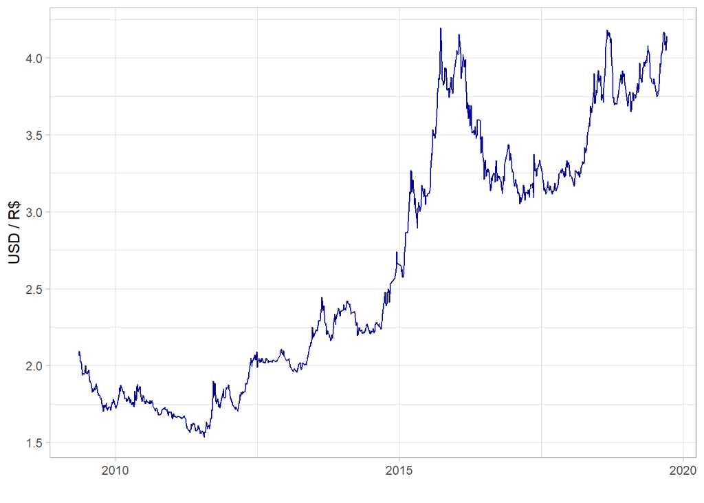

```r
ggplot(dados,aes(x=Data,y=Dolar))+
  geom_line(color='darkblue')+
  labs(y='USD / R$',x= '')+
  theme_light()
```

Gráfico DI

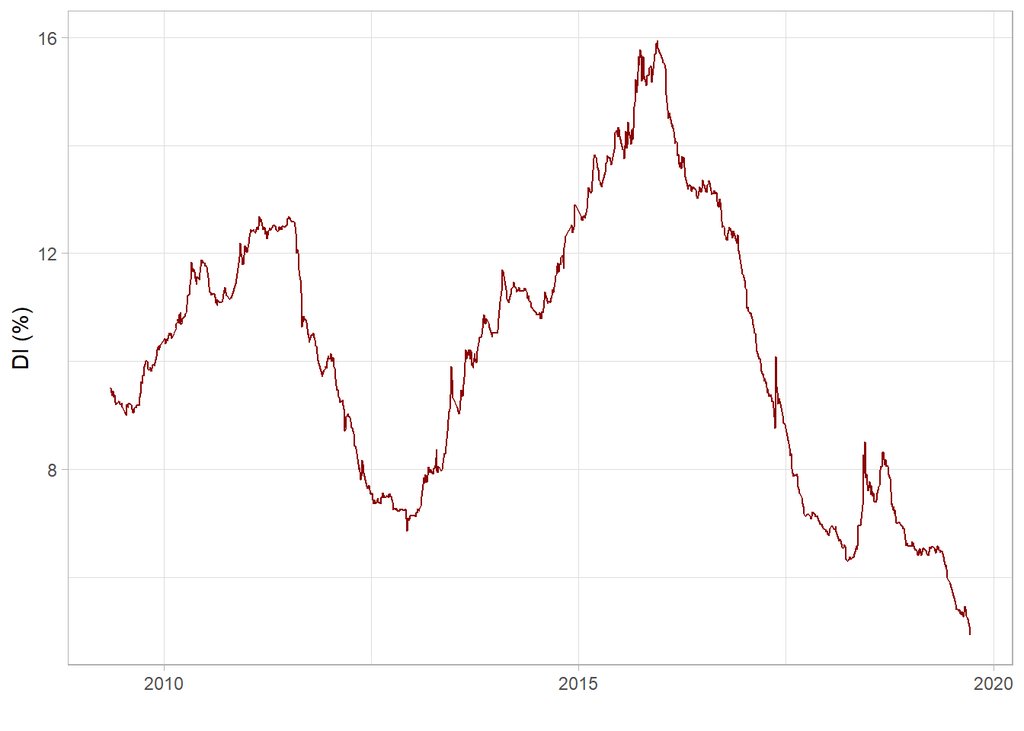

```r
ggplot(dados,aes(x=Data,y=DI))+
  geom_line(color='darkred')+
  labs(y='DI (%)',x='')+
  theme_light()
```

Gráfico EMBI

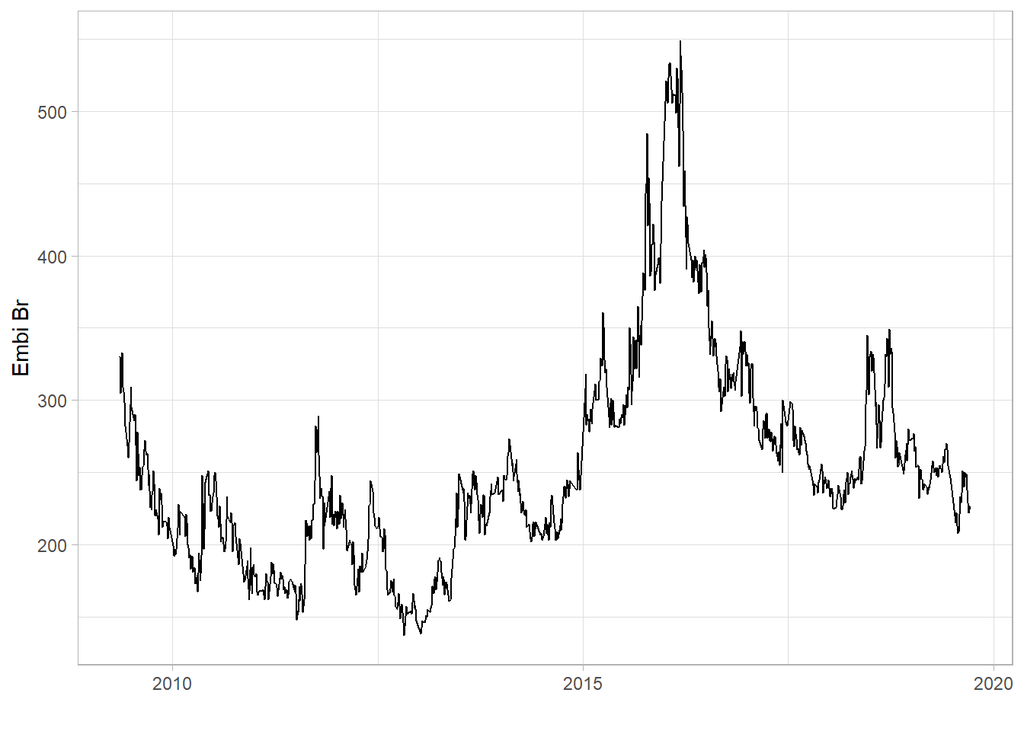

```r
ggplot(dados,aes(x=Data,y=EMBI))+
  geom_line(color='black')+
  labs(y='Embi Br',x= '')+
  theme_light()
```

Gráfico VIX

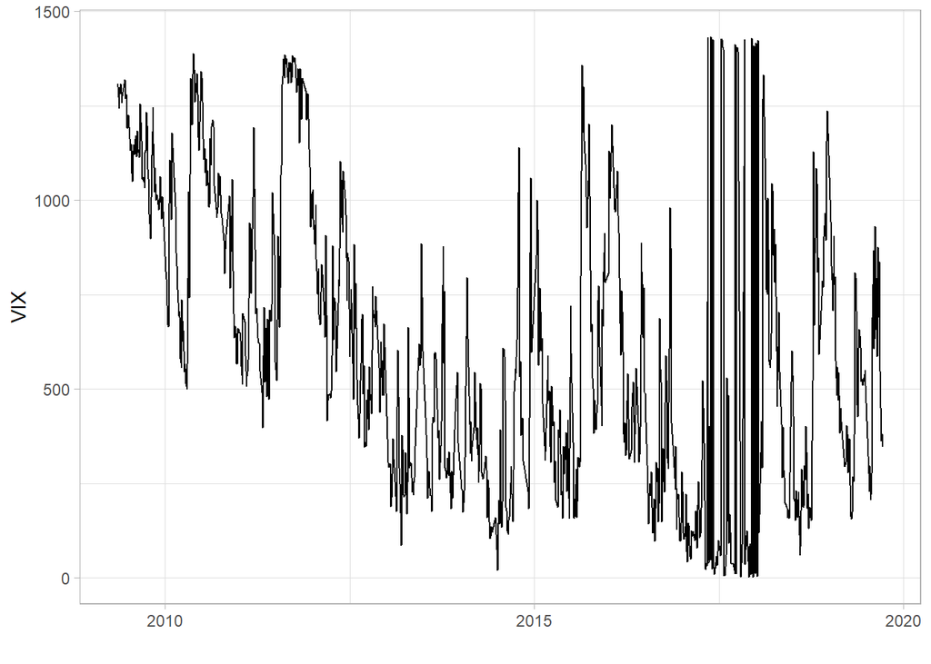

```r
ggplot(dados,aes(x=Data,y=VIX))+
  geom_line(color='black')+
  labs(x= '')+
  theme_light()
```

Gráfico DXY

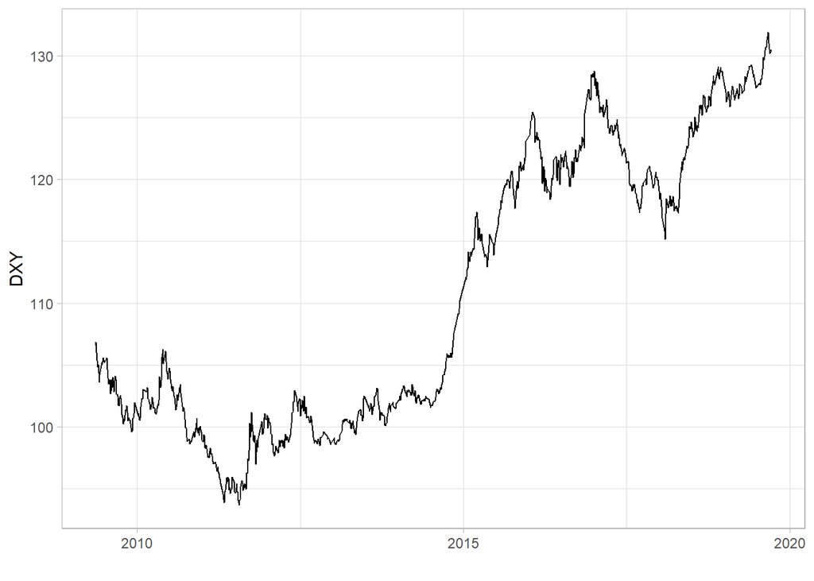

```r
ggplot(dados,aes(x=Data,y=DXY))+
  geom_line(color='black')+
  labs(x= '')+
  theme_light()
```

## Gráficos das variações

```r
dolar.s.t <- dados.sem.copom.t$`Dólar-terca`
dolar.s.q <- dados.sem.copom.q$`Dólar-quinta`
data.s <- dados.sem.copom.t$`Data- terça`
dolar.c.t <- dados.com.copom.t$`Dólar-terca`
dolar.c.q <- dados.com.copom.q$`Dólar-quinta`
data.c <- dados.com.copom.t$`Data-terca`

dolar.s <- log(dolar.s.q)-log(dolar.s.t)
dolar.c <- log(dolar.c.q)-log(dolar.c.t)

df.dol.s <- data.frame(data.s,dolar.s)
colnames(df.dol.s) <- c("data","dolar")
```

#### DI

Selecionando e organizando os dados

```r
di.s.t <- dados.sem.copom.t$`DI-terca`
di.s.q <- dados.sem.copom.q$`DI-quinta`


di.c.t <- dados.com.copom.t$`DI-terca`
di.c.q <- dados.com.copom.q$`DI-quinta`

di.s <- log(1+di.s.q)-log(1+di.s.t)
di.c <- log(1+di.c.q)-log(1+di.c.t)



df.dados.s <- data.frame(data.s,di.s,dolar.s)

colnames(df.dados.s) <- c('Ano','DI','DOLAR')

df.dados.c <- data.frame(data.c,di.c,dolar.c)
colnames(df.dados.c) <- c('Ano','DI','DOLAR')
```

Regressão para dias sem copom

```r
dds <- lm(dolar.s~di.s)
```

GGPLOT VARIAÇÕES SEM COPOM

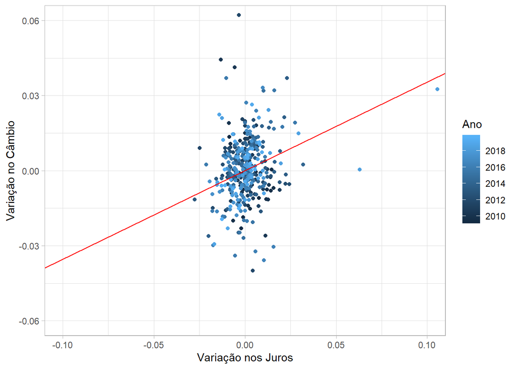

```r
p2.1 <- ggplot(data= df.dados.s)+
  geom_point(aes(x =DI, y =DOLAR,color=Ano))+
  labs(x="Variação nos Juros",y= "Variação no Câmbio")+
  geom_abline(intercept =0, slope = dds$coefficients[2],color='red')+
  # geom_abline(intercept =0, slope = ddc$coefficients[2],color='red')+
  theme_light()

p2.1 +coord_cartesian(xlim = c(-0.1, 0.1),ylim = c(-0.06,0.06))
```

```r
ddc <- lm(dolar.c~di.c)
```

VARIAÇÕES COM COPOM

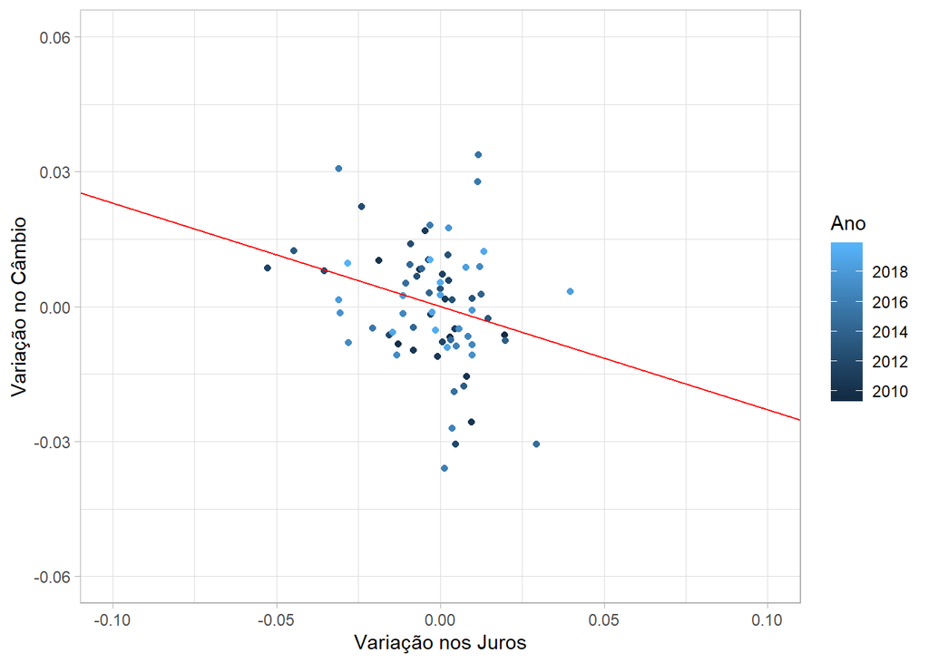

```r
p2.2 <- ggplot(data= df.dados.c)+
  geom_point(aes(x =DI, y =DOLAR,color=Ano))+
  labs(x="Variação nos Juros",y= "Variação no Câmbio")+
  geom_abline(intercept =0, slope = ddc$coefficients[2],color='red')+
  theme_light()


p2.2 +coord_cartesian(xlim = c(-0.1, 0.1),ylim = c(-0.06,0.06))
```

Unindo as variações dos dias com e sem copom. E ordenando os dados.

```r
df.dados.f <- rbind.data.frame(df.dados.c,df.dados.s)
df.dados.f <- df.dados.f[order(df.dados.f$Ano,decreasing = FALSE),]
```

VARIAÇÕES EM TODAS AS DATAS

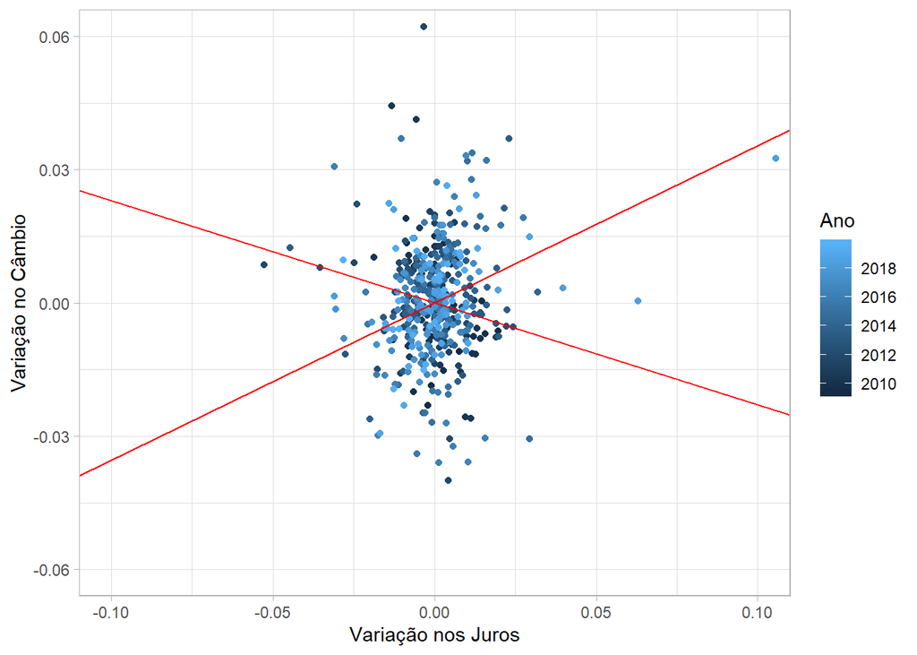

```r
p2.3 <- ggplot(data= df.dados.f)+
  geom_point(aes(x =DI, y =DOLAR,color=Ano))+
  labs(x="Variação nos Juros",y= "Variação no Câmbio")+
  geom_abline(intercept =0, slope = dds$coefficients[2],color='red')+
  geom_abline(intercept =0, slope = ddc$coefficients[2],color='red')+
  theme_light()


p2.3 +coord_cartesian(xlim = c(-0.1, 0.1),ylim = c(-0.06,0.06))
```

# TESTE F

```r
ddi.c <- di.c #difernça DI em encontros do copom

ddi.s <- di.s
```

TESTE F para a amostra do DI

```r
var.test(ddi.c,ddi.s)
```

```
##
##  F test to compare two variances
##
## data:  ddi.c and ddi.s
## F = 1.6449, num df = 72, denom df = 388, p-value = 0.003326
## alternative hypothesis: true ratio of variances is not equal to 1
## 95 percent confidence interval:
##  1.175797 2.405617
## sample estimates:
## ratio of variances
##           1.644894
```

```r
ddol.c <- dolar.c
ddol.s <- dolar.s
```

TESTE F para a amostra do Câmbio

```r
var.test(ddol.c,ddol.s)
```

```
##
##  F test to compare two variances
##
## data:  ddol.c and ddol.s
## F = 1.0387, num df = 72, denom df = 388, p-value = 0.8014
## alternative hypothesis: true ratio of variances is not equal to 1
## 95 percent confidence interval:
##  0.7424957 1.5191067
## sample estimates:
## ratio of variances
##           1.038723
```